# Predicting Hit Songs using Machine Learning

A song's popularity can be measured by its chart position.

For many musicians, getting their songs to chart high is of paramount importance in order garner a prominent presence in the music industry, and above all, to make money.

So now we ask:

- What do all these hit songs have in common?
- Is there a certain pattern or characteristics to determine a hit song?
- What are the significant and influential predictors?

In this project, we attempt to classify a song as a hit or non-hit based on its audio features. We used various machine learning algorithms such as Logistic Regression, Gaussian Naive Bayes, Decision Trees, and Random Forests for this binary classification problem and discuss whether or not audio features provide enough information for determining a hit song.

# Data Acquisition

[figure not shown]

We acquired data using Spotify's API for songs released in 2017. With Spotify's acquisition of Echo Nest, a music intelligence and data platform, their API allows users to access a song's audio features.

# Data Description

| Features | Description |
| --- | --- |
| acousticness | A confidence measure from 0.0 to 1.0 of whether the track is acoustic. 1.0 represents high confidence the track is acoustic. |
| danceability | Danceability describes how suitable a track is for dancing based on a combination of musical elements including tempo, rhythm stability, beat strength, and overall regularity. A value of 0.0 is least … |
| duration_ms | The duration of the track in milliseconds. |
| energy | Energy is a measure from 0.0 to 1.0 and represents a perceptual measure of intensity and activity. |
| instrumentalness | The closer the instrumentalness value is to 1.0, the greater likelihood the track contains no vocal content. Values above 0.5 are intended to represent instrumental tracks, but confidence is higher as… |
| liveness | Detects the presence of an audience in the recording. Higher liveness values represent an increased probability that the track was performed live. |
| loudness | The overall loudness of a track in decibels (dB). Values typical range between -60 and 0 db. |
| speechiness | Speechiness detects the presence of spoken words in a track. |
| tempo | The overall estimated tempo of a track in beats per minute (BPM). |
| valence | A measure from 0.0 to 1.0 describing the musical positiveness conveyed by a track. |
| artist_popularity | The popularity of the artist. The value will be between 0 and 100, with 100 being the most popular. |

## What is a "hit" song?

Spotipy: https://github.com/plamere/spotipy

Billboard: https://github.com/guoguo12/billboard-charts

## Sample Data

```python
df.head(10)
```

|  | acousticness | danceability | duration_ms | energy | instrumentalness | liveness | loudness | speechiness | tempo | valence | artist_popularity | hit | artist | track |
| --- | --- | --- | --- | --- | --- | --- | --- | --- | --- | --- | --- | --- | --- | --- |
| 0 | 0.469000 | 0.872 | 119133 | 0.391 | 0.000004 | 0.2970 | -9.144 | 0.2420 | 134.021 | 0.437 | 98 | 1 | XXXTENTACION | Jocelyn Flores |
| 1 | 0.017200 | 0.797 | 146520 | 0.533 | 0.000152 | 0.1030 | -9.740 | 0.0412 | 131.036 | 0.329 | 98 | 0 | XXXTENTACION | Fuck Love (feat. Trippie Redd) |
| 2 | 0.847000 | 0.734 | 95467 | 0.570 | 0.000021 | 0.1120 | -7.066 | 0.1330 | 129.953 | 0.689 | 98 | 1 | XXXTENTACION | Everybody Dies In Their Nightmares |
| 3 | 0.737000 | 0.483 | 203569 | 0.412 | 0.000000 | 0.1160 | -8.461 | 0.0402 | 170.163 | 0.247 | 93 | 0 | Billie Eilish | idontwannabeyouanymore |
| 4 | 0.149000 | 0.880 | 172800 | 0.428 | 0.000051 | 0.1140 | -8.280 | 0.2060 | 100.007 | 0.333 | 91 | 0 | Offset | Ric Flair Drip (& Metro Boomin) |
| 5 | 0.002640 | 0.732 | 182707 | 0.750 | 0.000000 | 0.1090 | -6.366 | 0.2310 | 155.096 | 0.401 | 89 | 1 | Lil Uzi Vert | XO TOUR Llif3 |
| 6 | 0.138000 | 0.718 | 156000 | 0.767 | 0.000000 | 0.1140 | -5.641 | 0.1660 | 160.084 | 0.519 | 85 | 0 | Lil Skies | Lust |
| 7 | 0.493000 | 0.763 | 190472 | 0.572 | 0.001180 | 0.1060 | -7.312 | 0.0595 | 151.930 | 0.250 | 73 | 0 | Bryce Vine | Drew Barrymore |
| 8 | 0.199000 | 0.798 | 202547 | 0.539 | 0.000017 | 0.1650 | -6.351 | 0.0421 | 136.949 | 0.394 | 96 | 1 | Khalid | Young Dumb & Broke |
| 9 | 0.000282 | 0.908 | 177000 | 0.621 | 0.000054 | 0.0958 | -6.638 | 0.1020 | 150.011 | 0.421 | 91 | 1 | Kendrick Lamar | HUMBLE. |

# Business Implications

[figure not shown]

Two target markets:

- Premium (87 million users) -- user generated revenue for paid service
  - No advertisements
  - Monthly subscription
- Ad-supported (109 million users) -- revenue generated through the sale of advertising
  - Free subscription

# Data Visualizations

## Linear Correlation Plot

[figure not shown]

## Histograms

[figure not shown]

## Boxplots

[figure not shown]

## Relevant Relationships

# Data Analysis

Since this is a binary classification problem, we used the following the models:

- Logistic Regression
- Gaussian Naive Bayes
- Decision Tree
- Random Forests

Models were trained with a random **70%** subset of our data, with the remaining **30%** designated to be used as validation.

And for evaluating the model, we will need to take consideration that our model has class imbalance: **287 hits and 6358 no-hits**.

We used confusion matrices to test the performance of our model. However, we cannot use Accuracy as an evaluation measure since our model can simply predict all as no-hits have achieve a ~95% accuracy rate.

Thus, we will use the **AUC** as it is a function of sensitivity and specificity, the curve is insensitive to disparities in the class proportions. Along with other metrics such as **f1-score, precision and recall**.

## Dealing with Class Imbalance

Pre-processing will be done via means of:

- Putting weights on errors proportional to the class imbalance.
  - Balanced vs Optimal Weighting
- Re-sample the data to balance the positive/negatives classes.
  - SMOTE: Synthetic Minority Over-sampling Technique

## Model 1: Logistic Regression

$ \begin{align} E(Y_i | X_i) = Pr(Y_i=1|X_i) = {\frac{1}{1 + e^{-(\beta_0 + \beta_1X_i)}}} \end{align} $

For any given x, The logistic response function will always yield to values in the interval [0,1].

Thus, if $(E(Y_i | X_i)<0.5)$, then the logistic model predicts $y = 0$ and, alternatively, if $E(Y_i | X_i)>0.5$ the model predicts $y = 1$.

Type of questions we attempted to answer with a binary logistic regression:

- What predictors have an significant influence on the probability of a song being a hit?
- How does the probability of a hit song change for every additional unit change in our predictors?

Below is a summary of all our logistic models' performance:

[output not shown]

```python
pd.DataFrame(np.exp(logisticRegr.coef_.toarray()), columns=predictors)
```

|  | acousticness | energy | instrumentalness | liveness | loudness | speechiness | tempo | artist_popularity |
| --- | --- | --- | --- | --- | --- | --- | --- | --- |
| 0 | 0.70321 | 0.761105 | 0.766846 | 0.861689 | 1.310214 | 1.023295 | 1.005722 | 2.313017 |

## Model 2: Gaussian Naive Bayes

The second method that we will explore is Gaussian Naive Bayes.

As we learned in class, Naive Bayes incorporate the concept of conditional probability, or the probability of event A given that event B has occurred.

However, since we're dealing with continuous data, we'll have to make an assumption that the continuous values associated with each class are distributed according to a Gaussian distribution.

Hence, we will be looking at the probability of event (hit = 1) given that its predictor values are $x_i$ where the probability of $x_i$ can be computed by plugging $x_i$ into a Gaussian distribution parameterized by $\mu _{k}$ and $\sigma _{k}^{2}$.

Unfortunately, we weren't able to train a well-performing Gaussian Naive Bayes model and were only able to marginally beat the un-preprocessed model's performance.

| Method | Precision | Recall | F1-Score | AUC |
| --- | --- | --- | --- | --- |
| Gaussian Naive Bayes (NO pre-processing) | 0.27 | 0.17 | 0.21 | 0.765 |
| Gaussian Naive Bayes (Calculated Priors) | 0.14 | 0.47 | 0.21 | 0.765 |
| Gaussian Naive Bayes (SMOTE + optimal ratio) | 0.26 | 0.11 | 0.16 | 0.769 |

## Model 3: Decision (Classification) Trees

Decision trees are one of the most transparent and easy to interpret machine learning algorithms.

It involves separating observations into subgroups by creating splits on predictors.

And as such, these splits create logical rules that are easily understandable. An example logical rule could be, for example:

`If artist popularity is >= X, then the probability of a song being a hit is Y`

### Gini Importance

Before we attempt pre-processing, we can attempt to further improve our model by actually selecting features that provides good impurity reduction (the measure based on which the (locally) optimal condition is chosen is called impurity).

The Gini impurity index is defined as:

Where $n_c$ is the number of classes in the target variable and $p_i$ is the ratio of this class.

```python
feature_imp = pd.Series(
    decTree.feature_importances_,
    index=predictors).sort_values(ascending=False)
feature_imp
```

```
speechiness          0.158337
acousticness         0.127041
energy               0.115353
loudness             0.114175
valence              0.102860
danceability         0.100144
liveness             0.089092
artist_popularity    0.082173
tempo                0.081514
instrumentalness     0.029311
dtype: float64
```

| Method | Precision | Recall | F1-Score | AUC |
| --- | --- | --- | --- | --- |
| Decision Trees (No pre-processing) | 0.16 | 0.21 | 0.18 | 0.579 |
| Decision Trees (After feature-reduction) | 0.19 | 0.25 | 0.22 | 0.600 |
| Decision Trees (Balanced Class Weights) | 0.23 | 0.27 | 0.25 | 0.615 |
| Decision Trees (Calculated Weights) | 0.17 | 0.2 | 0.18 | 0.578 |
| Decision Trees (SMOTE) | 0.12 | 0.36 | 0.19 | 0.625 |
| Decision Trees (SMOTE + optimal ratio) | 0.15 | 0.29 | 0.20 | 0.609 |

A much comprehensive decision tree can be seen here (zoom-in for detail): https://i.imgur.com/ciG996z.png

## Model 4: Random Forests

To address the shortcomings of a single tree (like we trained above), with poor predictive power, we can attempt to combine results from multiple trees. This is an example of an ensemble method known as random forests (multiple trees = forests).

Random forests is basically conducted in a few steps:

1. Draw multiple samples, with replacement, from our data (known as bootstrapping).
2. Train a classification decision tree to each sample.
3. Combine the classifications from the individual trees to obtain a majority voted result. (i.e. if we trained 100 trees, we classify a song as a hit if > 50 trees voted yes).

| Method | Precision | Recall | F1-Score | AUC |
| --- | --- | --- | --- | --- |
| Random Forests (No pre-processing) | 0.83 | 0.13 | 0.22 | 0.764 |
| Random Forests (After feature-reduction) | 1.00 | 0.12 | 0.21 | 0.759 |
| Random Forests (Balanced Class Weights) | 1.00 | 0.10 | 0.19 | 0.761 |
| Random Forests (Calculated Weights) | 0.80 | 0.10 | 0.18 | 0.716 |
| Random Forests (SMOTE) | 0.18 | 0.28 | 0.22 | 0.736 |
| Random Forests (SMOTE + optimal ratio) | 0.56 | 0.18 | 0.27 | 0.754 |

# Model Summary (Performance Evaluation)

| Method | Precision | Recall | F1-Score | AUC |
| --- | --- | --- | --- | --- |
| Logistic Regression (NO pre-processing) | 0 | 0 | 0 | 0.732 |
| Logistic Regression (Balanced Class Weights) | 0.1 | 0.65 | 0.17 | 0.727 |
| Logistic Regression (Calculated Weights) | 0.17 | 0.27 | 0.21 | 0.734 |
| Logistic Regression (SMOTE) | 0.1 | 0.67 | 0.18 | 0.734 |
| Logistic Regression (SMOTE + optimal ratio) | 0.17 | 0.31 | 0.22 | 0.729 |
| Gaussian Naive Bayes (NO pre-processing) | 0.27 | 0.17 | 0.21 | 0.765 |
| Gaussian Naive Bayes (Calculated Priors) | 0.14 | 0.47 | 0.21 | 0.765 |
| Gaussian Naive Bayes (SMOTE + optimal ratio) | 0.26 | 0.11 | 0.16 | 0.769 |
| Decision Trees (No pre-processing) | 0.16 | 0.21 | 0.18 | 0.579 |
| Decision Trees (After feature-reduction) | 0.19 | 0.25 | 0.22 | 0.600 |
| Decision Trees (Balanced Class Weights) | 0.23 | 0.27 | 0.25 | 0.615 |
| Decision Trees (Calculated Weights) | 0.17 | 0.2 | 0.18 | 0.578 |
| Decision Trees (SMOTE) | 0.12 | 0.36 | 0.19 | 0.625 |
| Decision Trees (SMOTE + optimal ratio) | 0.15 | 0.29 | 0.20 | 0.609 |
| Random Forests (No pre-processing) | 0.83 | 0.13 | 0.22 | 0.764 |
| Random Forests (After feature-reduction) | 1.00 | 0.12 | 0.21 | 0.759 |
| Random Forests (Balanced Class Weights) | 1.00 | 0.10 | 0.19 | 0.761 |
| Random Forests (Calculated Weights) | 0.80 | 0.10 | 0.18 | 0.716 |
| Random Forests (SMOTE) | 0.18 | 0.28 | 0.22 | 0.736 |
| Random Forests (SMOTE + optimal ratio) | 0.56 | 0.18 | 0.27 | 0.754 |

Since Random Forests provided great performance we can attempt to evaluate the model on the entire dataset and see their results.

```
[[6357    1]
 [  89  198]]
              precision    recall  f1-score   support

       False       0.99      1.00      0.99      6358
        True       0.99      0.69      0.81       287

   micro avg       0.99      0.99      0.99      6645
   macro avg       0.99      0.84      0.90      6645
weighted avg       0.99      0.99      0.99      6645
```

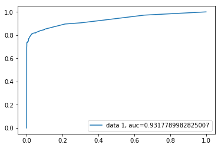

```python
# Un-preprocessed
plt.show()
```

```
[[6356    2]
 [  67  220]]
              precision    recall  f1-score   support

       False       0.99      1.00      0.99      6358
        True       0.99      0.77      0.86       287

   micro avg       0.99      0.99      0.99      6645
   macro avg       0.99      0.88      0.93      6645
weighted avg       0.99      0.99      0.99      6645
```

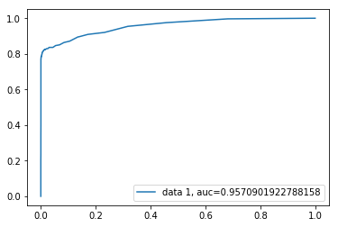

```python
# Feature-reduced
plt.show()
```

```
[[6354    4]
 [  67  220]]
              precision    recall  f1-score   support

       False       0.99      1.00      0.99      6358
        True       0.98      0.77      0.86       287

   micro avg       0.99      0.99      0.99      6645
   macro avg       0.99      0.88      0.93      6645
weighted avg       0.99      0.99      0.99      6645
```

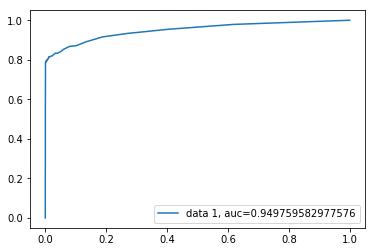

```python
# Balanced Class Weights
plt.show()
```

Here are the compiled results:

| Method | Precision | Recall | F1-Score | AUC |
| --- | --- | --- | --- | --- |
| Random Forests (Un-preprocessed) | 0.99 | 0.69 | 0.81 | 0.931 |
| Random Forests (After feature reduction) | 0.99 | 0.77 | 0.86 | 0.957 |
| Random Forests (Balanced Class Weights) | 0.98 | 0.77 | 0.86 | 0.949 |

Overall, the two pre-processed methods did beat the beat the benchmark set by the un-preprocessed method with higher recall scores!

For curiosity, here is a random subset of 30 songs that both the two pre-processed method predicted to be hits:

```python
data.loc[(data.RF1_pred) & (data.RF2_pred), ["track", "artist"]].sample(n=30)
```

|  | track | artist |
| --- | --- | --- |
| 234 | Like I Loved You | Brett Young |
| 151 | Mercy | Shawn Mendes |
| 697 | Every Little Thing | Russell Dickerson |
| 19 | Bank Account | 21 Savage |
| 4549 | DNA. | Kendrick Lamar |
| 959 | Slide | Calvin Harris |
| 150 | Rake It Up | Yo Gotti |
| 68 | When It Rains It Pours | Luke Combs |
| 5779 | Friends | Dbangz |
| 155 | Selfish | PnB Rock |
| 676 | Love So Soft | Kelly Clarkson |
| 40 | Unforgettable | French Montana |
| 4429 | Heavy | POWERS |
| 106 | Mercy | Brett Young |
| 507 | 2U | David Guetta |
| 260 | Rolex | Ayo & Teo |
| 6109 | Silence | Our Last Night |
| 652 | More Girls Like You | Kip Moore |
| 131 | Transportin' | Kodak Black |
| 401 | Light It Up | Luke Bryan |
| 3676 | Closer | POWERS |
| 45 | Body Like A Back Road | Sam Hunt |
| 594 | Black SpiderMan | Logic |
| 392 | Drinkin' Problem | Midland |
| 7313 | Plain Jane | A$AP Ferg |
| 1626 | Better Man | Little Big Town |
| 5151 | Look What You Made Me Do | The Mayries |
| 830 | X | Lil Uzi Vert |
| 4287 | Congratulations | Shy Glizzy |
| 192 | Chanel | Frank Ocean |